# Session 24: General linear model

In this notebook we will connect the ideas of correlation with the concept of linear regression.

```r
library(dplyr)
```

```r
library(ggplot2)
```

Let’s generate a simple dataset.

```r
set.seed(12345)
betas=c(2,5)  # the number of points that having a prior class increases grades
df=data.frame(studyTime=c(2,3,5,6,6,8,10,12),
              priorClass=c(0,1,1,0,1,0,1,0)) %>%
  mutate(grade=studyTime*betas[1]+priorClass*betas[2] +round(rnorm(8,mean=70,sd=5)))
df
```

| studyTime | priorClass | grade |
| --- | --- | --- |
| 2 | 0 | 77 |
| 3 | 1 | 85 |
| 5 | 1 | 84 |
| 6 | 0 | 80 |
| 6 | 1 | 90 |
| 8 | 0 | 77 |
| 10 | 1 | 98 |
| 12 | 0 | 93 |

```r
lmResult=lm(grade~studyTime,data=df)

print(summary(lmResult))
```

```
##
## Call:
## lm(formula = grade ~ studyTime, data = df)
##
## Residuals:
##     Min      1Q  Median      3Q     Max
## -10.656  -2.719   0.125   4.703   7.469
##
## Coefficients:
##             Estimate Std. Error t value Pr(>|t|)
## (Intercept)   76.156      5.161  14.756 6.09e-06 ***
## studyTime      1.438      0.714   2.013   0.0907 .
## ---
## Signif. codes:  0 '***' 0.001 '**' 0.01 '*' 0.05 '.' 0.1 ' ' 1
##
## Residual standard error: 6.386 on 6 degrees of freedom
## Multiple R-squared:  0.4032, Adjusted R-squared:  0.3037
## F-statistic: 4.054 on 1 and 6 DF,  p-value: 0.09073
```

```r
lmResultIntercept=lm(grade~1,data=df)
anova(lmResult,lmResultIntercept)
```

|  | Res.Df | RSS | Df | Sum of Sq | F | Pr(>F) |
| --- | --- | --- | --- | --- | --- | --- |
| 1 | 6 | 244.6875 | NA | NA | NA | NA |
| 2 | 7 | 410.0000 | -1 | -165.3125 | 4.05364 | 0.09073051 |

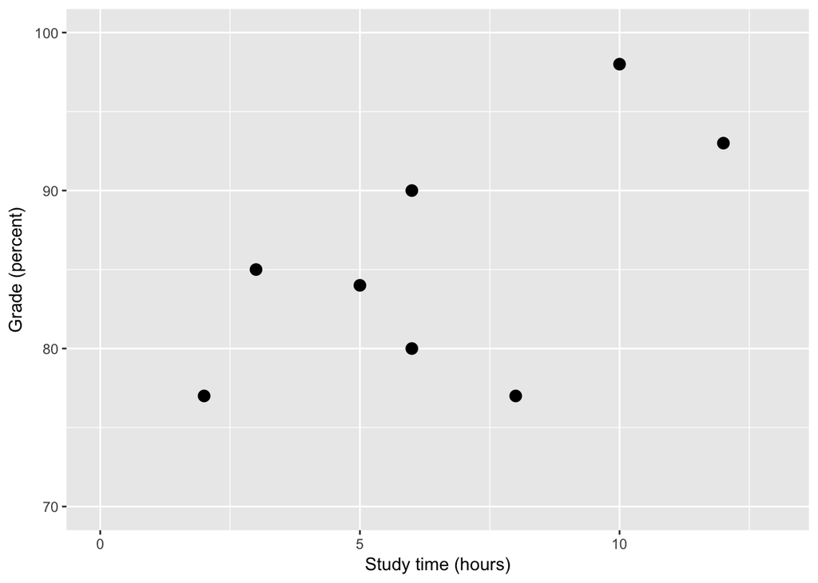

```r
p=ggplot(df,aes(studyTime,grade)) +
  geom_point(size=3) +
  xlab('Study time (hours)') +
  ylab('Grade (percent)') +
  xlim(0,13) +
  ylim(70,100)

print(p)
```

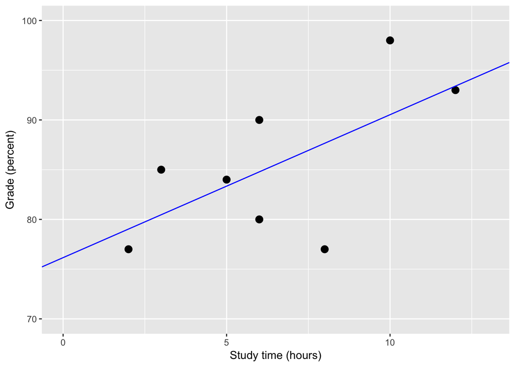

```r
ggsave('studyTimePlot.png')
p2=p+geom_abline(slope=lmResult$coefficients[2],
                  intercept=lmResult$coefficients[1],
                  color='blue')

print(p2)
```

```r
cor.test(df$studyTime,df$grade)
```

```
##
##  Pearson's product-moment correlation
##
## data:  df$studyTime and df$grade
## t = 2.0134, df = 6, p-value = 0.09073
## alternative hypothesis: true correlation is not equal to 0
## 95 percent confidence interval:
##  -0.1261283  0.9255245
## sample estimates:
##       cor
## 0.6349813
```

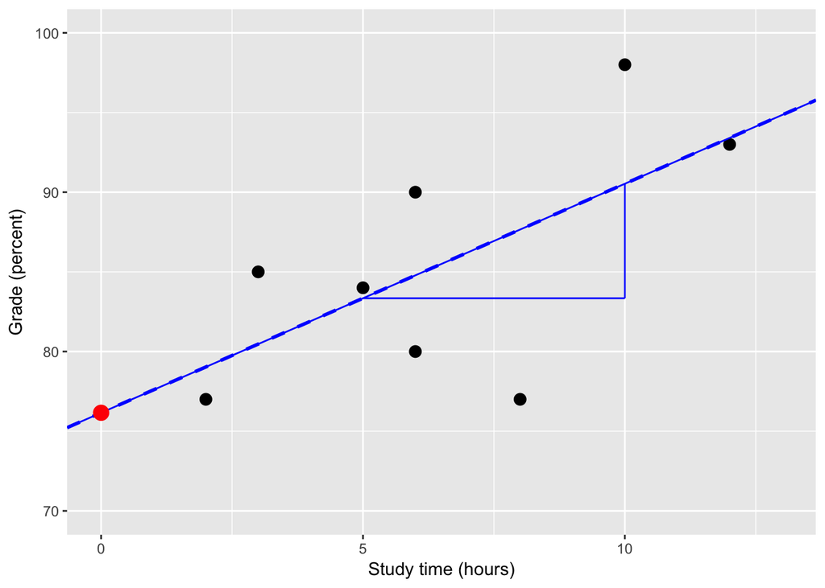

```r
p3=p2+geom_abline(slope=lmResult$coefficients[2],
                  intercept=lmResult$coefficients[1],
                  color='blue',linetype='dashed',size=1) +
  annotate('point',x=0,y=lmResult$coefficients[1],color='red',size=4) +
  annotate('segment',x=5,xend=10,color='blue',
           y=predict(lmResult,newdata=data.frame(studyTime=5))[1],
           yend=predict(lmResult,newdata=data.frame(studyTime=5))[1]) +
   annotate('segment',x=10,xend=10,color='blue',
           y=predict(lmResult,newdata=data.frame(studyTime=5))[1],
           yend=predict(lmResult,newdata=data.frame(studyTime=10))[1])

print(p3)
```

```r
predict(lmResult,newdata=data.frame(studyTime=5))[1] -predict(lmResult,newdata=data.frame(studyTime=10))[1]
```

```
##       1
## -7.1875
```

Let’s compute the regression slope directly from the data. Intuitively, we want to see whether deviations from the mean are related in the X and Y variables; that, when X is oddly large, is Y also oddly large, and vice versa?

```r
# first compute the sum of squared error from the mean
df = df %>%
  mutate(studyTimeResid=studyTime-mean(studyTime),
         gradeResid=grade - mean(grade)) %>%
  mutate(crossproduct=studyTimeResid*gradeResid)

sum(df$crossproduct)
```

```
## [1] 115
```

```r
sum(df$studyTimeResid**2)
```

```
## [1] 80
```

```r
bHat = sum(df$crossproduct)/sum(df$studyTimeResid**2)

df
```

| studyTime | priorClass | grade | studyTimeResid | gradeResid | crossproduct |
| --- | --- | --- | --- | --- | --- |
| 2 | 0 | 77 | -4.5 | -8.5 | 38.25 |
| 3 | 1 | 85 | -3.5 | -0.5 | 1.75 |
| 5 | 1 | 84 | -1.5 | -1.5 | 2.25 |
| 6 | 0 | 80 | -0.5 | -5.5 | 2.75 |
| 6 | 1 | 90 | -0.5 | 4.5 | -2.25 |
| 8 | 0 | 77 | 1.5 | -8.5 | -12.75 |
| 10 | 1 | 98 | 3.5 | 12.5 | 43.75 |
| 12 | 0 | 93 | 5.5 | 7.5 | 41.25 |

#### More complex models

Now let’s examine a case where we have two independent variables. Let’s say that grades are actually a function of study time as well as prior experience with the topic of the course. We will code prior experience using a 1 to denote that the individual has had a prior class in the topic, and a zero to indicate that they have not. This is what we call “dummy coding”. Intuitively, the coefficient on this variable should indicate the effect of having had a prior class:

$$grade = \hat{\beta_1}*studyTime + \hat{\beta_2}*priorClass + \hat{\beta_0}$$

```r
df$grade[df$grade>100]=100
df$grade[df$grade<0]=0
df$priorClass=as.factor(df$priorClass)

lmResultTwoVars = lm(grade ~ studyTime + priorClass,data=df)
summary(lmResultTwoVars)
```

```
##
## Call:
## lm(formula = grade ~ studyTime + priorClass, data = df)
##
## Residuals:
##        1        2        3        4        5        6        7        8
##  3.58333  0.75000 -3.58333 -0.08333  0.75000 -6.41667  2.08333  2.91667
##
## Coefficients:
##             Estimate Std. Error t value Pr(>|t|)
## (Intercept)  70.0833     3.7680  18.600 8.27e-06 ***
## studyTime     1.6667     0.4553   3.661   0.0146 *
## priorClass1   9.1667     2.8793   3.184   0.0244 *
## ---
## Signif. codes:  0 '***' 0.001 '**' 0.01 '*' 0.05 '.' 0.1 ' ' 1
##
## Residual standard error: 4.021 on 5 degrees of freedom
## Multiple R-squared:  0.8028, Adjusted R-squared:  0.724
## F-statistic: 10.18 on 2 and 5 DF,  p-value: 0.01726
```

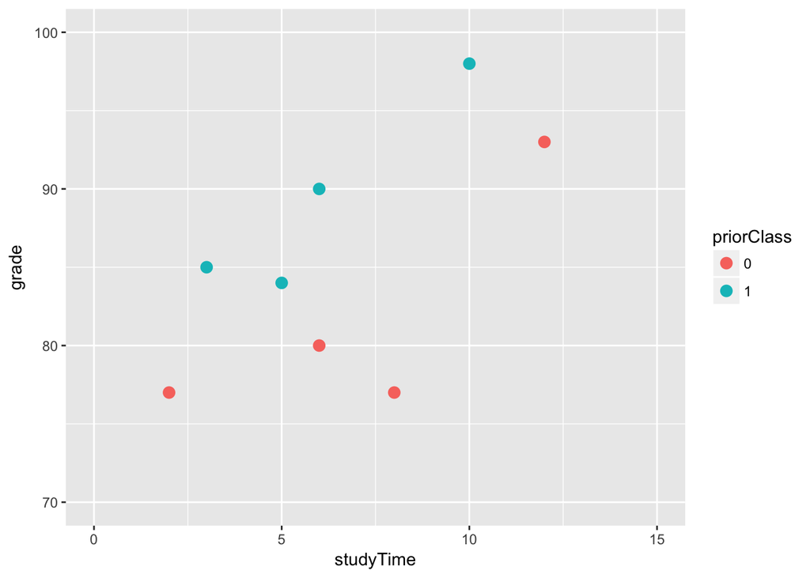

```r
p=ggplot(df,aes(studyTime,grade,color=priorClass)) +
  geom_point(size=3) + xlim(0,15) + ylim(70,100)
print(p)
```

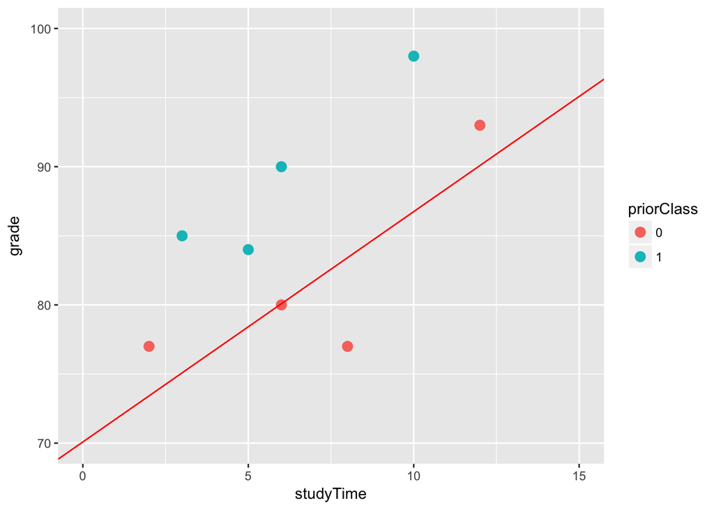

```r
p=p+
  geom_abline(slope=lmResultTwoVars$coefficients[2],
              intercept=lmResultTwoVars$coefficients[1],color='red')
print(p)
```

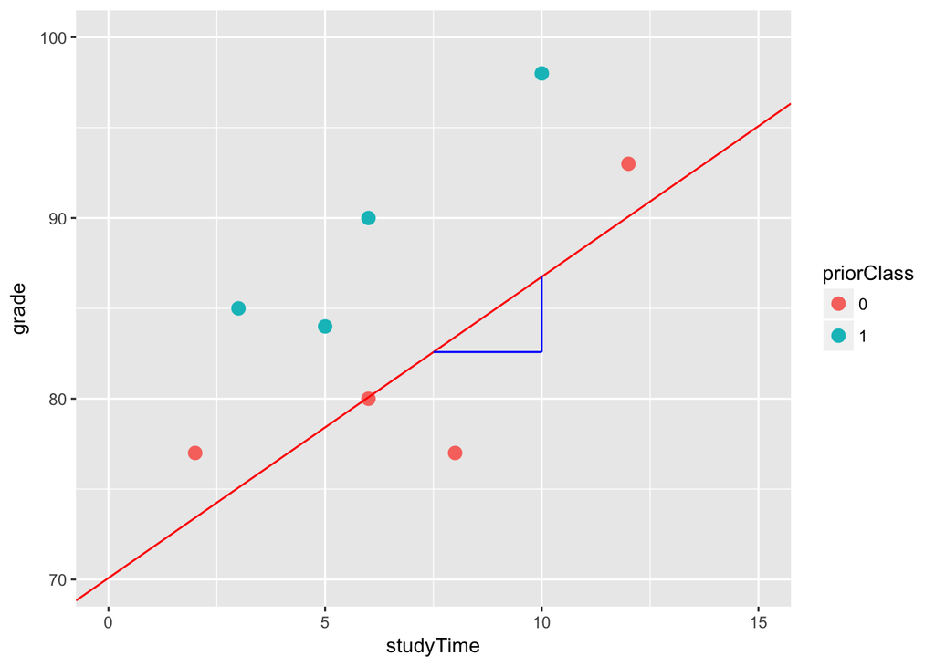

```r
p=p+
  annotate('segment',x=7.5,xend=10,
           y=lmResultTwoVars$coefficients[1]+
             7.5*lmResultTwoVars$coefficients[2],
           yend=lmResultTwoVars$coefficients[1]+
             7.5*lmResultTwoVars$coefficients[2],
           color='blue') +
  annotate('segment',x=10,xend=10,
           y=lmResultTwoVars$coefficients[1]+
             7.5*lmResultTwoVars$coefficients[2],
           yend=lmResultTwoVars$coefficients[1]+
             10*lmResultTwoVars$coefficients[2],
           color='blue')


print(p)
```

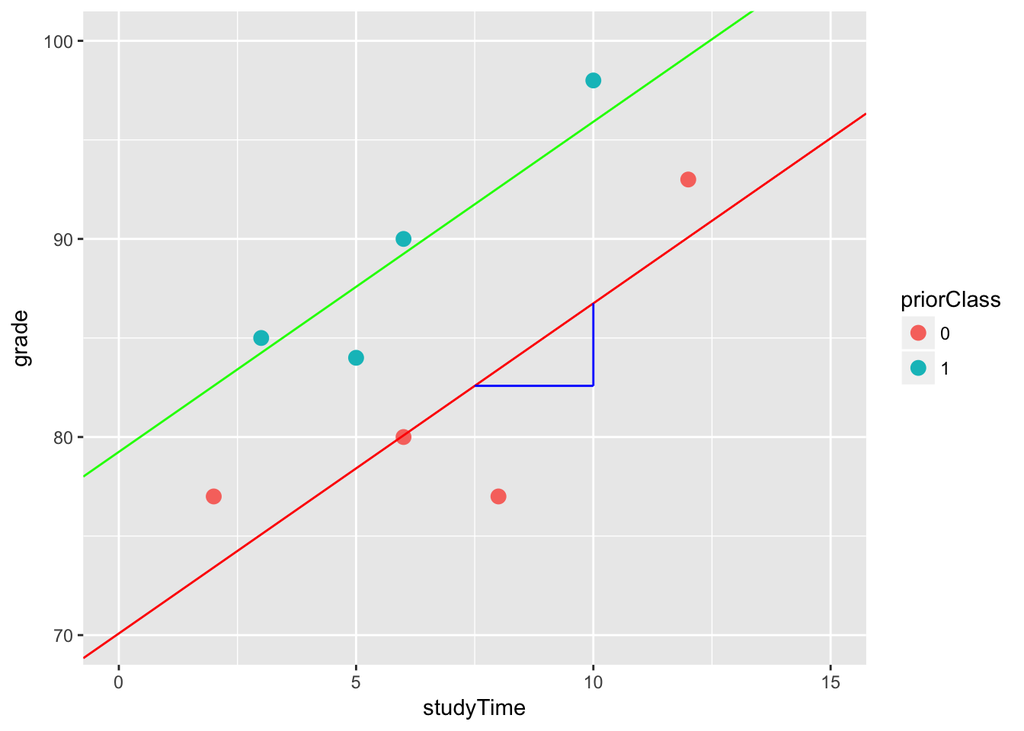

```r
p=p+
  geom_abline(slope=lmResultTwoVars$coefficients[2],
              intercept=lmResultTwoVars$coefficients[1]+
                lmResultTwoVars$coefficients[3],
              color='green')
print(p)
```

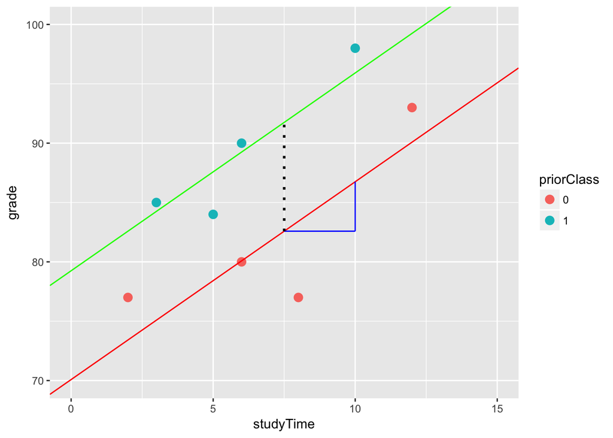

```r
p=p+
  annotate('segment',x=7.5,xend=7.5,
           y=lmResultTwoVars$coefficients[1]+
             7.5*lmResultTwoVars$coefficients[2],
           yend=lmResultTwoVars$coefficients[1]+
             lmResultTwoVars$coefficients[3] +
             7.5*lmResultTwoVars$coefficients[2],
           linetype='dotted',size=1)
print(p)
```

```r
df %>% summarize()
```

#### Interactions in linear models

What if the effect of one variable changes as a function of another variable? Let’s take the example of how public speaking ability varies with caffeine intake.

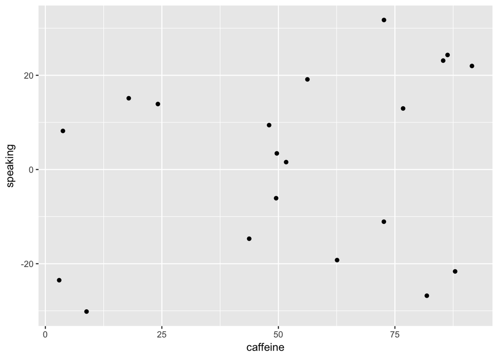

```r
set.seed(1234567)
df=data.frame(group=c(rep(-1,10),rep(1,10))) %>%
  mutate(caffeine=runif(n())*100) %>%
  mutate(speaking=0.5*caffeine*-group + group*20 + rnorm(20)*10)

p=ggplot(df,aes(caffeine,speaking)) +
  geom_point()
print(p)
```

First run the linear model with just caffeine as an independent variable.

```r
lmResultCaffeine = lm(speaking~caffeine,data=df)
summary(lmResultCaffeine)
```

```
##
## Call:
## lm(formula = speaking ~ caffeine, data = df)
##
## Residuals:
##     Min      1Q  Median      3Q     Max
## -33.096 -16.024   5.014  16.453  26.979
##
## Coefficients:
##             Estimate Std. Error t value Pr(>|t|)
## (Intercept)  -7.4132     9.1653  -0.809    0.429
## caffeine      0.1676     0.1508   1.111    0.281
##
## Residual standard error: 19.19 on 18 degrees of freedom
## Multiple R-squared:  0.06419,    Adjusted R-squared:  0.0122
## F-statistic: 1.235 on 1 and 18 DF,  p-value: 0.2811
```

But now let’s say that we find research suggesting that anxious and non-anxious people react differently to caffeine. First let’s plot the data separately for anxious and non=anxious people.

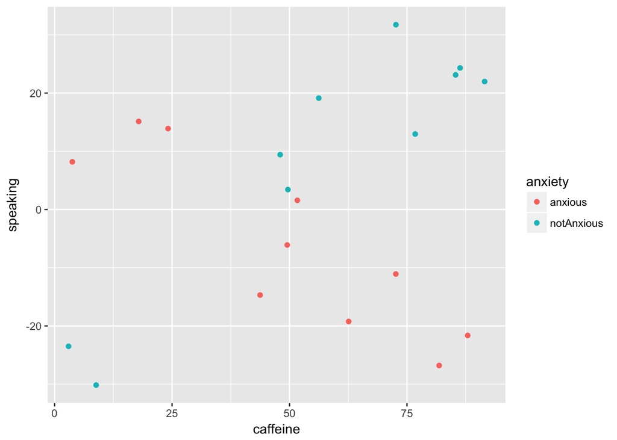

```r
df = df %>% mutate(anxiety=ifelse(group==1,'anxious','notAnxious'))
p=ggplot(df,aes(caffeine,speaking,color=anxiety)) +
  geom_point()
print(p)
```

Now we see that anxious people seem to perform better at low levels of caffeine while non-anxious people perform better with more caffeine. First let’s see what happens if we just include anxiety in the model.

```r
lmResultCafAnx = lm(speaking ~ caffeine + anxiety,data=df)
summary(lmResultCafAnx)
```

```
##
## Call:
## lm(formula = speaking ~ caffeine + anxiety, data = df)
##
## Residuals:
##     Min      1Q  Median      3Q     Max
## -32.968  -9.743   1.351  10.530  25.361
##
## Coefficients:
##                   Estimate Std. Error t value Pr(>|t|)
## (Intercept)       -12.5812     9.1967  -1.368    0.189
## caffeine            0.1313     0.1446   0.908    0.377
## anxietynotAnxious  14.2328     8.2324   1.729    0.102
##
## Residual standard error: 18.21 on 17 degrees of freedom
## Multiple R-squared:  0.2041, Adjusted R-squared:  0.1105
## F-statistic:  2.18 on 2 and 17 DF,  p-value: 0.1436
```

Here we see there are no significant effects of either caffeine or anxiety, but that seems wrong. The problem is that this model is trying to fit the same line relating speaking to caffeine for group. If we want to fit them using separate lines, we can include an *interaction* in the model, which is equivalent to fitting different lines for the two groups.

```r
lmResultInteraction = lm(speaking ~ caffeine + anxiety + caffeine*anxiety,data=df)
summary(lmResultInteraction)
```

```
##
## Call:
## lm(formula = speaking ~ caffeine + anxiety + caffeine * anxiety,
##     data = df)
##
## Residuals:
##     Min      1Q  Median      3Q     Max
## -11.385  -7.103  -0.444   6.171  13.458
##
## Coefficients:
##                             Estimate Std. Error t value Pr(>|t|)
## (Intercept)                 17.43085    5.43012   3.210 0.005461 **
## caffeine                    -0.47416    0.09664  -4.906 0.000158 ***
## anxietynotAnxious          -43.44873    7.79141  -5.576 4.17e-05 ***
## caffeine:anxietynotAnxious   1.08395    0.12931   8.382 3.01e-07 ***
## ---
## Signif. codes:  0 '***' 0.001 '**' 0.01 '*' 0.05 '.' 0.1 ' ' 1
##
## Residual standard error: 8.085 on 16 degrees of freedom
## Multiple R-squared:  0.8524, Adjusted R-squared:  0.8247
## F-statistic:  30.8 on 3 and 16 DF,  p-value: 7.014e-07
```

Now we see that there are effects of both caffeine and anxiety (which we call *main effects*) and an interaction between caffeine and anxiety.

We can visualize them by plotting separate lines describing the predicted values for the two groups.

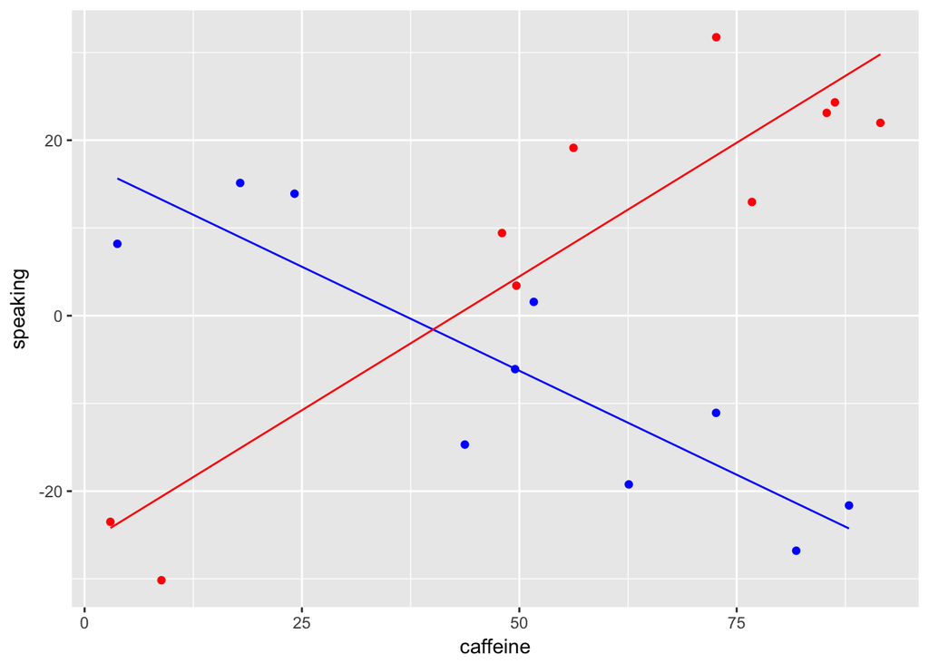

```r
df_anx=df%>%subset(anxiety=='anxious')
df_notanx=df%>%subset(anxiety=='notAnxious')

p=ggplot(df_anx,aes(caffeine,speaking)) +
  geom_point(color='blue') +
  geom_line(data=data.frame(x=df$caffeine[df$anxiety=='anxious'],
                    y=lmResultInteraction$fitted.values[df$anxiety=='anxious']),
            aes(x,y),color='blue') +
  geom_point(data=df_notanx,aes(caffeine,speaking),color='red')+
  geom_line(data=data.frame(x=df$caffeine[df$anxiety=='notAnxious'],
                    y=lmResultInteraction$fitted.values[df$anxiety=='notAnxious']),
            aes(x,y),color='red')
print(p)
```

We can also compare the goodness of fit of the model with and without the interaction, using the anova() command.

```r
anova(lmResultCafAnx,lmResultInteraction)
```

|  | Res.Df | RSS | Df | Sum of Sq | F | Pr(>F) |
| --- | --- | --- | --- | --- | --- | --- |
| 1 | 17 | 5639.314 | NA | NA | NA | NA |
| 2 | 16 | 1045.937 | 1 | 4593.377 | 70.26621 | 3.00976e-07 |